# 9 — Convolutional networks 2: special blocks

Machine Learning (MPA-MLR)

Roman Jakubíček · Jiří Chmelík

Department of Biomedical Engineering · FEEC, Brno University of Technology

2026

## Outline

1 · Skip connections

Short and long connections across layers, and the two ways of joining the data.

2 · Residual block

Identity plus a learned residual; why depth stops hurting so much.

3 · 1 × 1 convolution, bottleneck

Mixing features in depth; the cheap bottleneck block of ResNet-50.

4 · Dilated convolution

A larger receptive field with the same number of weights.

5 · Shrink and grow back

Autoencoders, unpooling, transposed convolution — the way to U-Net.

6 · Attention module

Where the network should look — channel and spatial attention.

## 1 · Skip connections

> Last time ReLU, batch normalization and initialization kept the gradient alive — and yet deeper plain networks still train worse.

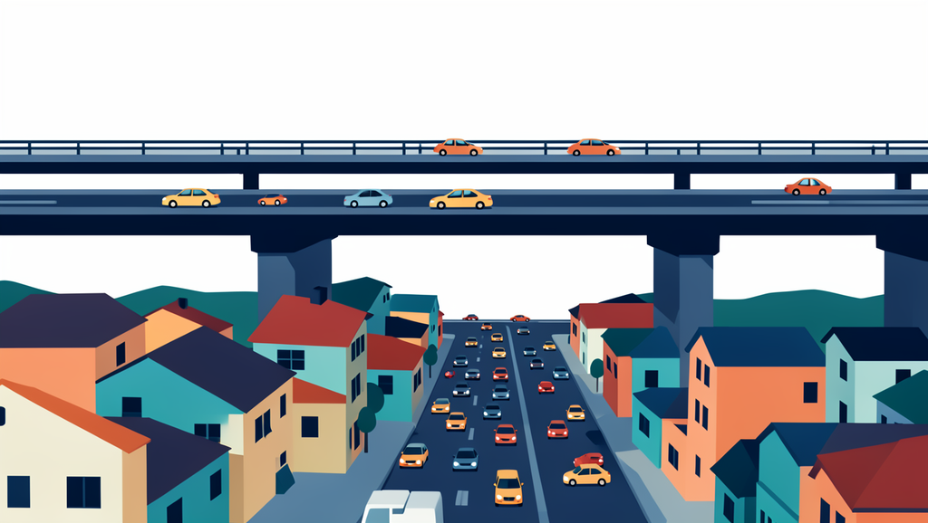

Illustration generated by AI (FLUX.2)

## Skip connections

Short and long

**Short** skips jump over a block, **long** skips run across the network

Information flow

Detailed early maps reach the deep layers

Gradient flow

Helps against **vanishing** gradients in deep nets

[figure not shown]

… but how can we join the data?

## Why skip connections help

The gradient at layer $l$ is a **product of Jacobians** of all the layers above — with every layer contracting a little, it shrinks exponentially.

A residual layer $\mathbf h_l = \mathbf h_{l-1} + f(W_l \mathbf h_{l-1} + \mathbf b_l)$ has

$$\frac{\partial \mathbf h_l}{\partial \mathbf h_{l-1}} = I + \operatorname{diag}\big(f'(\mathbf z_l)\big)\, W_l$$

— the identity adds a **direct term** $I$.

30 `tanh` layers at initialization: at the output $0.025$ (plain) and $0.030$ (residual); back at layer 1 the plain gradient is **3.3× smaller**, the residual one **35.5× larger**.

[figure not shown]

[code example — residual block and the gradient](https://github.com/tomasvicar/MLR-public/blob/master/lectures/L9/code/residual_block.py)

## Joining data — concatenation

- **Concatenation:** stack the maps along the **depth**
- $W \times H$ must match; the depths **add up**

$$A^*_l = [A_i, A_l], \quad i < l,
\qquad \text{e.g.}\quad A^*_4 = [A_1, A_4]$$

[figure not shown]

✓ Nothing is lost

The next layer decides with its own weights how much of each source it uses.

✗ The price

The output is deeper — more memory, more weights in the next convolution.

## Joining data — addition

- **Addition:** element-wise sum — the identity bypasses the layers in between
- **all three** sizes must match; the output keeps the depth

$$A^*_l = A_i + A_l, \quad i < l,
\qquad \text{e.g.}\quad A^*_4 = A_1 + A_4$$

[figure not shown]

✓ No extra memory

The output keeps the shape — blocks can be chained.

✗ One shared space

Both tensors share one space; all three sizes must match.

Rule of thumb

**U-Net concatenates, ResNet adds.**

## 2 · Residual block

> The block that made 100-layer networks trainable — and it is one addition.

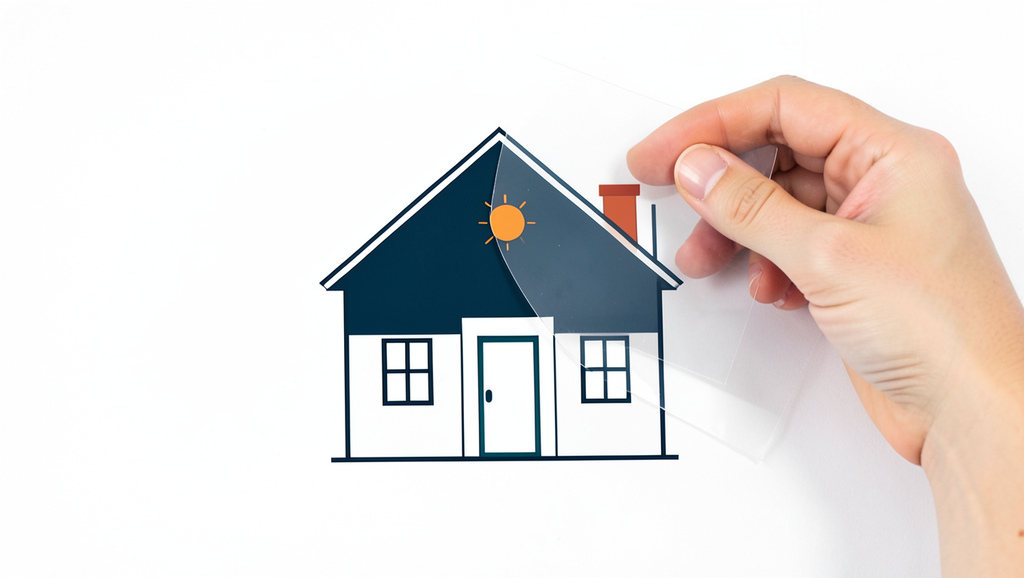

Illustration generated by AI (FLUX.2)

## Residual block

Input

map $\mathbf x$

Output

$\mathcal F(\mathbf x) + \mathbf x$, the **same shape**

Hyperparameters

layers in the branch; the variant

Learned parameters

the branch only; the identity **none**

- **Deeper ≥ shallower** in principle — the extra layers could be the identity
- …but deeper plain nets are **harder to optimize**
- The convolutions learn the **residual**, $\mathcal H(\mathbf x)$ is the desired mapping:

$$\mathcal F(\mathbf x) = \mathcal H(\mathbf x) - \mathbf x$$

Identity = all branch weights zero — easy to reach; the gradient flows through $\mathbf x$.

[figure not shown]

## Deeper is not automatically better

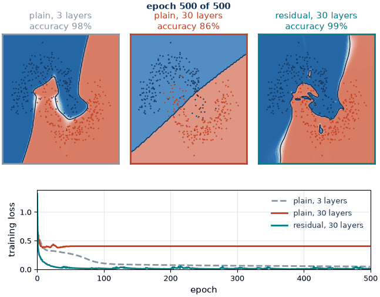

Three `tanh` networks — the same data, optimizer and initial weights (where they share layers):

3 layers, plain

loss $0.049$, accuracy $97.5\,\%$

30 layers, plain

stuck at $0.40$ and $86\,\%$: *deeper is worse*

30 layers, residual

`h = h + tanh(W @ h + b)`: loss $0.018$, accuracy $99.25\,\%$

[code example — residual block and the gradient](https://github.com/tomasvicar/MLR-public/blob/master/lectures/L9/code/residual_block.py)

## Residual block — variations

- (a), (b): a ReLU or batch normalization (BN) **after the addition**
- (c)–(e): a **clean identity**; they differ in the order **inside the branch**
- a **1 × 1 convolution** on the identity branch when the depths differ

[figure not shown]

Drawn after He et al., *Identity Mappings in Deep Residual Networks*, ECCV 2016 ([arXiv:1603.05027](https://arxiv.org/abs/1603.05027)), Fig. 4.

## 3 · 1 × 1 convolution and bottleneck

> A convolution that sees a single pixel — and is one of the most useful blocks there is.

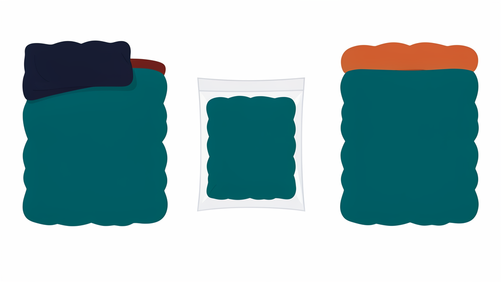

Illustration generated by AI (FLUX.2)

## 1 × 1 convolution layer

Input

map $W \times H \times D$

Output

$W \times H \times K$ — same $W \times H$, new depth

Hyperparameters

the number of filters $K$

Learned parameters

$K \cdot D$ weights $+$ $K$ biases

- also called **pointwise** convolution
- mixes features **in depth**, not in space
- each output map = a **linear combination** of the input maps

[figure not shown]

## 1 × 1 convolution — pixel by pixel

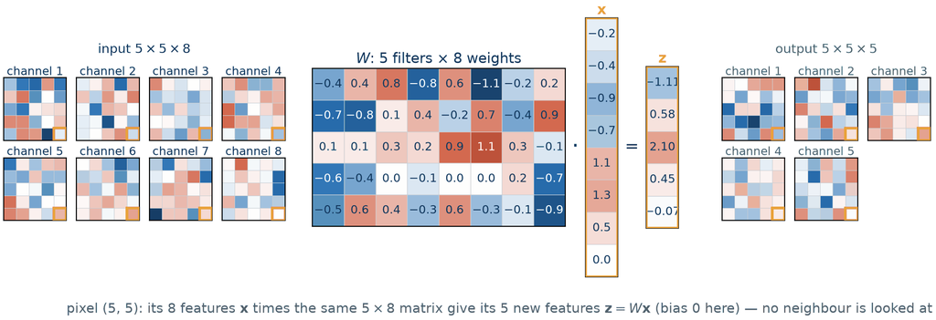

The same layer on a $5 \times 5$ crop: at every pixel $\mathbf z = W \mathbf x + \mathbf b$ with **one** $5 \times 8$ matrix — the 40 weights of the table on the next slide.

## Why use a 1 × 1 convolution?

Uses

- **new combinations** of features
- **reduce** or **expand** the number of features
- **speed-up** by reducing the depth
- **depthwise separable** convolution (MobileNet)
- a **fully connected** layer, written as a convolution

Cost

For the layer from the two previous slides: $256 \times 256 \times 8 \rightarrow 256 \times 256 \times 5$

| kernel | weights | biases | MACs / pixel |
| --- | --- | --- | --- |
| $1 \times 1$ | $1 \cdot 1 \cdot 8 \cdot 5 = 40$ | 5 | 40 |
| $3 \times 3$ | $3 \cdot 3 \cdot 8 \cdot 5 = 360$ | 5 | 360 |

MAC = multiply–accumulate. Nine times fewer weights and operations — but no spatial context.

A $1 \times 1$ convolution applied to a $1 \times 1 \times D$ tensor **is** a fully connected layer: the same weights, the same output.

## Bottleneck — reduction of the feature dimension

[figure not shown]

The spatial size stays, the depth shrinks — done by the $1 \times 1$ convolution: $524\,288 \to 256 \cdot 256 \cdot 4 = 262\,144$ values, only **2×** fewer. The saving is in the *next* layer, which works on 4 features instead of 8.

## Bottleneck layer

- **1 × 1** narrows the depth, the **3 × 3** works on it, **1 × 1** widens it back
- a large **saving** in weights and computation
- the bottleneck block of **ResNet-50** and deeper; a $1 \times 1$ reduction also in GoogLeNet/Inception and DenseNet

[figure not shown]

## Bottleneck layer — what it saves

|  | weights | MACs for a $300 \times 300$ map |
| --- | --- | --- |
| $3 \times 3$ conv, 512 filters (direct) | $3 \cdot 3 \cdot 512 \cdot 512 = 2\,359\,296$ | $2.12 \cdot 10^{11}$ |
| $1 \times 1$ conv, 64 filters | $512 \cdot 64 = 32\,768$ | $2.95 \cdot 10^{9}$ |
| $3 \times 3$ conv, 64 filters | $3 \cdot 3 \cdot 64 \cdot 64 = 36\,864$ | $3.32 \cdot 10^{9}$ |
| $1 \times 1$ conv, 512 filters | $64 \cdot 512 = 32\,768$ | $2.95 \cdot 10^{9}$ |
| **bottleneck, total** | **$102\,400$** | **$9.22 \cdot 10^{9}$** |

23 × fewer weights and 23 × less arithmetic — for the same input and output shape.

## Playground: what does the bottleneck save?

[interactive chart not shown]

Direct 3 × 3 convolution **D → D** against the bottleneck **D → D′ → D′ → D** (1 × 1, 3 × 3, 1 × 1). Biases left out, as in the table.

depth of the map **D** =

bottleneck width **D′** =

map size **W = H** =

## 4 · Dilated convolution

> Nine weights, but a window as big as you like — and the output keeps its full resolution.

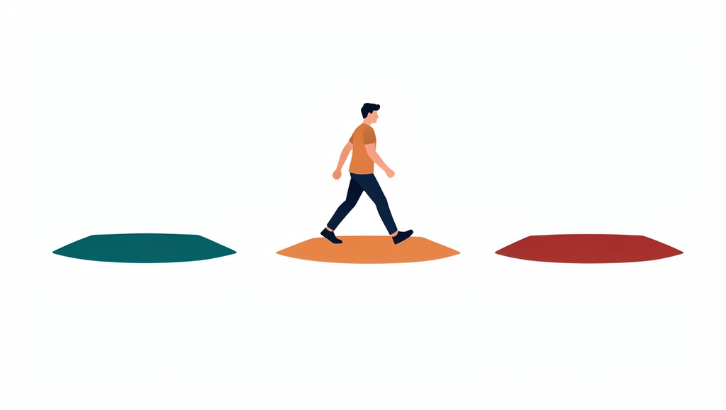

Illustration generated by AI (FLUX.2)

## Dilated convolution

Input

map $W \times H \times D$

Output

the same $W \times H$ — **no down-sampling**

Hyperparameters

$F$, dilation $\delta$, $K$; $P = (F-1)\delta/2$

Learned parameters

as an ordinary convolution — $\delta$ adds **none**

Aggregates **context at several scales** — a larger receptive field without down- and up-sampling.

Standard convolution

$$z(i,j) = \sum_{u}\sum_{v} x(i+u,\, j+v)\; w(u,v)$$

Dilated convolution, dilation $\delta$

$$z(i,j) = \sum_{u}\sum_{v} x(i+\delta u,\, j+\delta v)\; w(u,v)$$

with $u, v = -1, 0, 1$ for a $3 \times 3$ kernel.

[figure not shown]

Drawn after Yu & Koltun, *Multi-Scale Context Aggregation by Dilated Convolutions*, ICLR 2016 ([arXiv:1511.07122](https://arxiv.org/abs/1511.07122)).

## Dilated convolution — the kernel sliding

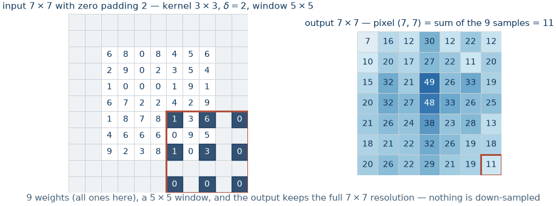

All nine weights are $1$, so every output pixel is the sum of the nine sampled values — check any of them by hand. Window $5 \times 5$, zero padding $P = 2$, and the output keeps the **same $7 \times 7$ size**.

## Dilated convolution — the receptive field

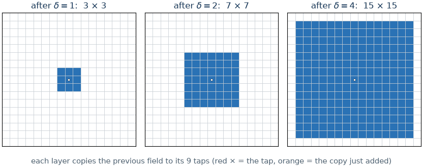

Dilated, δ = 1, 2, 4

A $3 \times 3$ kernel with dilation $\delta$ covers $(F-1)\delta + 1$ pixels; three of them reach $3 \to 7 \to 15$ — with $3 \times 9 = 27$ weights.

Ordinary 3 × 3

Three of them reach only $3 \to 5 \to 7$; a $15 \times 15$ kernel would need 225 weights.

[code example — dilated convolution and the receptive field](https://github.com/tomasvicar/MLR-public/blob/master/lectures/L9/code/dilated_convolution.py)

## Playground: choose the dilations

[interactive chart not shown]

Three 3 × 3 convolutions in a chain. The map shows the input pixels that reach the **centre** output pixel; darker = more paths. Pink = a hole inside the field.

layer 1: δ<sub>1</sub> =

layer 2: δ<sub>2</sub> =

layer 3: δ<sub>3</sub> =

path counts

## 5 · Shrink and grow back

> Squeeze the input through a narrow spot, then grow it back — segmentation and generation need the way back up.

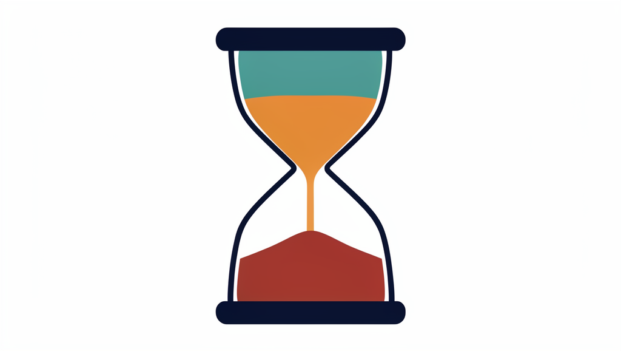

Illustration generated by AI (FLUX.2)

## Bottleneck — autoencoders

- a **narrow layer** limits what can pass → a learned **compression**
- a **trade-off** between accuracy and compression
- trained **without labels** — the input is the target:

$$\hat{\mathbf w} = \arg\min_{\mathbf w}
\sum_{i=1}^{n} \lVert \mathbf x_i - \hat{\mathbf x}_i(\mathbf w) \rVert_2^2$$

- without the bottleneck the network could just **copy** the input

**Applications:** dimensionality reduction · the encoder–decoder shape (segmentation) · bottleneck layers (the third block).

[figure not shown]

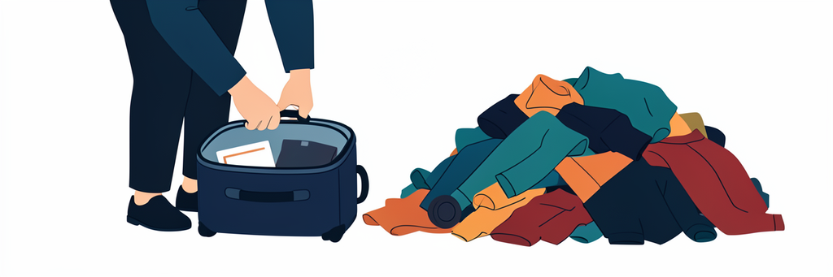

Illustration generated by AI (FLUX.2)

## Bottleneck — feature reduction by PCA

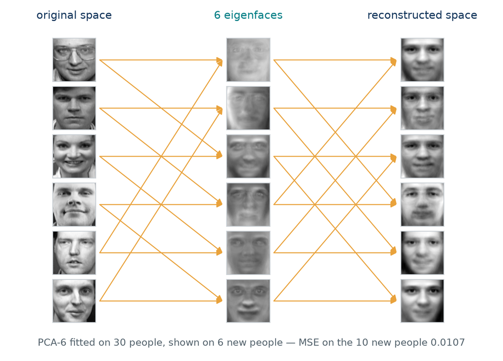

Principal component analysis (PCA) fitted on **30 people** (300 faces), shown on **10 new people**.

Olivetti faces (AT&T Laboratories Cambridge), computed by [the code example](https://github.com/tomasvicar/MLR-public/blob/master/lectures/L9/code/autoencoder_vs_pca.py).

## Bottleneck — feature reduction by a neural net

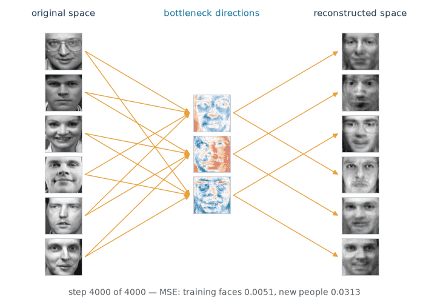

A linear encoder, a nonlinear decoder ($3 \to 64 \to 4096$, tanh). Training faces: mean squared error (MSE) $0.0051$ (PCA-3: $0.0100$). **New people: $0.0313$** — worse than the mean face ($0.0245$).

Olivetti faces (AT&T Laboratories Cambridge), computed by [the code example](https://github.com/tomasvicar/MLR-public/blob/master/lectures/L9/code/autoencoder_vs_pca.py).

## Bottleneck — and on new faces?

[figure not shown]

| MSE | training | new people |
| --- | --- | --- |
| mean face | 0.0179 | 0.0245 |
| PCA-3 | 0.0100 | **0.0129** |
| PCA-9 | 0.0065 | 0.0096 |
| autoencoder (AE) $3 \to 64 \to 4096$ | **0.0051** | 0.0313 |
| AE $3 \to 8 \to 4096$, regularized | 0.0104 | 0.0140 |

A bottleneck alone does **not** prevent overfitting. Regularized, the autoencoder generalizes — but with 400 faces, linear PCA is hard to beat.

## Bottleneck — how narrow can it be?

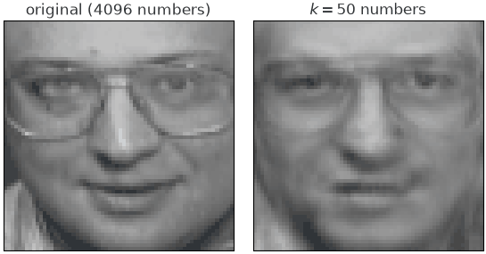

[figure not shown]

$k = 0$ is the mean face; on the training faces each extra component removes a little less error; on new people the curve lies higher and flattens out too.

## Bottleneck — reduction of the spatial dimension

[figure not shown]

Down-sampling (pooling or a strided convolution) shrinks $W$ and $H$ and keeps the depth: $256 \cdot 256 \cdot 8 = 524\,288$ values become $32 \cdot 32 \cdot 8 = 8\,192$ — **64× fewer**. Doubling the depth of the narrow map to 16 still gives a 32× compression.

## Up-sampling layers

**Segmentation** and **generation** need maps back at full resolution.

Unpooling

puts the maxima back to their **positions** (switches)

Transposed convolution

a convolution run backwards, **learned** kernel

Interpolation

bilinear or nearest, **nothing to learn**

Only the middle one has parameters. Unpooling needs the positions remembered from pooling; interpolation needs nothing at all.

## Up-sampling — the same map three ways

[figure not shown]

The same $2 \times 2$ input, three different $4 \times 4$ outputs — only the transposed convolution has **learned** weights.

## Unpooling layer (max)

Input

pooled map + **switch variables** (where each maximum was)

Output

the size before pooling; the maximum at its position, **zeros** elsewhere

Hyperparameters

window and stride of the paired max pooling

Learned parameters

**none**

- reverses **max pooling** — the **positions** only; after average pooling, interpolate instead

[figure not shown]

Drawn after Zeiler & Fergus, *Visualizing and Understanding Convolutional Networks*, ECCV 2014 ([arXiv:1311.2901](https://arxiv.org/abs/1311.2901)).

## Unpooling — a worked example

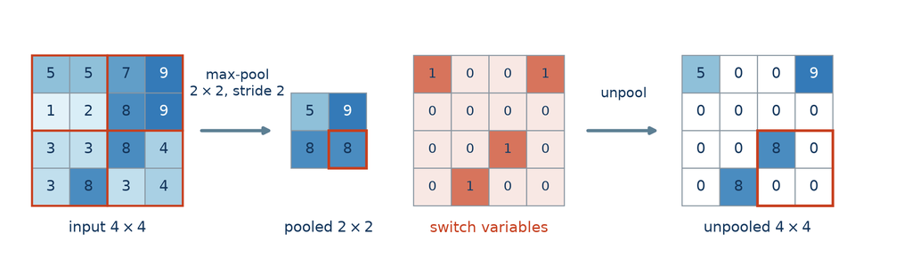

Max pooling $2 \times 2$ with stride 2 keeps 4 of the 16 values, so unpooling can put back **4 numbers out of 16** — the rest is zero. The switch variables cost one index per pooled value.

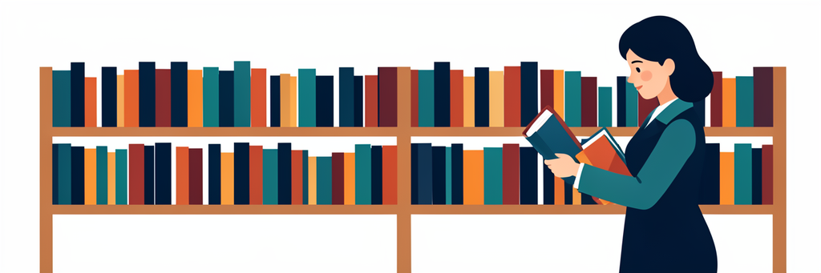

Illustration generated by AI (FLUX.2)

## Convolution as a matrix product

The convolution of the previous lecture (one channel):
$$z(i,j) = \sum_{u}\sum_{v} x(i+u,\, j+v)\; w(u,v)$$
It is **linear** in $X$ → it is a **matrix product**:

$$\operatorname{vec}(Z) = C \, \operatorname{vec}(X)$$

$X$ input, $Z$ output, $C$ the **convolution matrix**.

No inverse with stride S > 1

$C$ has $\lceil M/S \rceil^2$ rows and $M^2$ columns — it is **not square**.

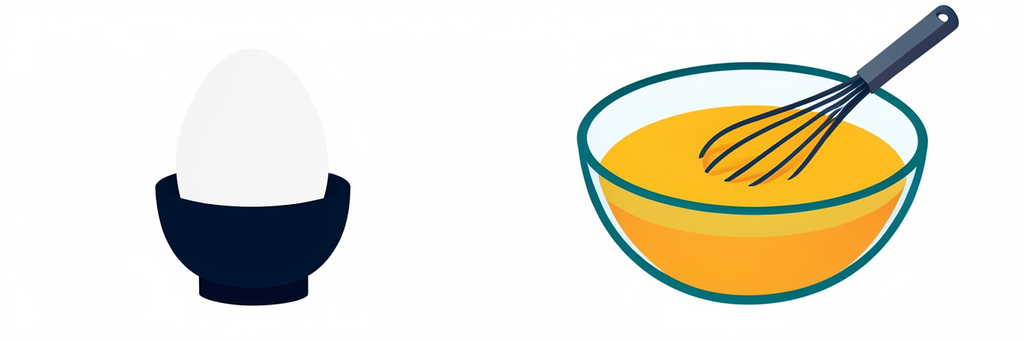

Illustration generated by AI (FLUX.2)

But we can use the convolution matrix to up-sample $Z$ back to the size of $X$.

## Transposed convolution — padding and vectorization

- **transposed convolution** undoes the *shape* change of a strided convolution — sometimes wrongly called “deconvolution”
- first write the convolution as a matrix product:
- **pad** $N \times N$ to $M \times M$, $M = N + (F - 1)$
- **vectorize** row by row → length $M^2$

Kernel $W$ ($F = 3$):
$$W = \begin{bmatrix}
w_{1,1} & w_{1,2} & w_{1,3} \\
w_{2,1} & w_{2,2} & w_{2,3} \\
w_{3,1} & w_{3,2} & w_{3,3}
\end{bmatrix}$$

Padded image and its vectorization:
$$X = \begin{bmatrix}
x_{1,1} & \cdots & x_{1,M} \\
\vdots & \ddots & \vdots \\
x_{M,1} & \cdots & x_{M,M}
\end{bmatrix}
\;\Rightarrow\;
\operatorname{vec}(X) = \begin{bmatrix}
x_{1,1} \\ x_{1,2} \\ \vdots \\ x_{M,M}
\end{bmatrix}
\!\!\begin{array}{l} \\ \\ \\ M^2 \end{array}$$

In the matrix derivation the window is anchored at its **top-left corner**: $w_{1,1}$ multiplies $x(i, j)$, i.e. the offsets $u, v$ run from $0$ to $F - 1$.

## Convolution matrix C — stride 1 and stride 2

**Each row of $C$ is one position of the kernel**; the three groups of weights are the three kernel rows, $M$ columns apart.

[figure not shown]

## Convolution matrix — a worked example

[figure not shown]

$N = 3$, $F = 3$, so $M = 5$ and $C$ is $25 \times 25$ with at most $9$ non-zeros per row — $144$ of the $625$ entries, $23\,\%$. Here $C$ is square and, because $w_{1,1} \neq 0$, invertible: $\det C = w_{1,1}^{25}$, but $\mathrm{cond}\, C = 147$.

[code example — the convolution matrix, checked against `scipy.signal.correlate2d`](https://github.com/tomasvicar/MLR-public/blob/master/lectures/L9/code/transposed_convolution.py)

## Convolution matrix — built row by row

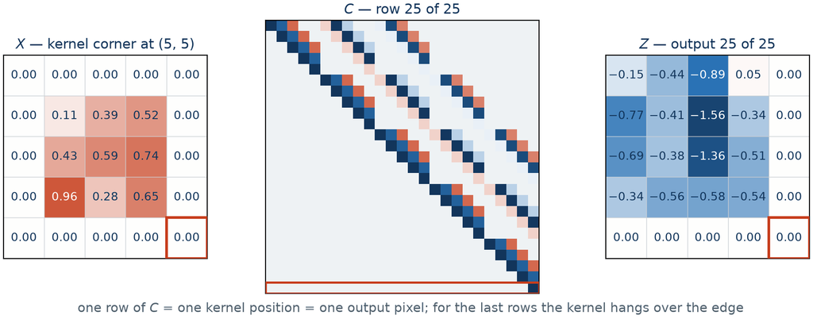

The kernel with its corner at $(i, j)$ is row $(i-1)M + j$ of $C$; its nine weights land in the columns of the pixels it covers. Positions that hang over the edge have fewer entries — the last one only $w_{1,1}$.

## Transposed convolution — the two steps

[figure not shown]

For a real $256 \times 256$ map, $C$ would have $4 \cdot 10^{9}$ entries — the matrix form is a derivation, not an implementation.

## Transposed convolution — up-sampling

**Up-sampling:** multiply by $C^\top$ — the length goes back to $M^2$. In a network $C$ is built from a **learned** kernel: the same sparse shape, only $F^2$ free weights.

[figure not shown]

$$\text{convolution:}\quad \operatorname{vec}(Z) = C\, \operatorname{vec}(X)
\qquad\qquad
\text{transposed:}\quad \operatorname{vec}(Y) = C^{\top} \operatorname{vec}(Z)$$

## Transposed convolution — the example continued

[figure not shown]

The same kernel on a $5 \times 5$ map with stride 2: $C$ is $\lceil 5/2 \rceil^2 \times 25 = 9 \times 25$, $Z$ is $3 \times 3$ and $C^\top \operatorname{vec}(Z)$ is again $5 \times 5$. **The shape is restored, the values are not** — the relative error against $X$ is $122\,\%$.

[code example — the convolution matrix, checked against `scipy.signal.correlate2d`](https://github.com/tomasvicar/MLR-public/blob/master/lectures/L9/code/transposed_convolution.py)

## Transposed convolution — what the product does

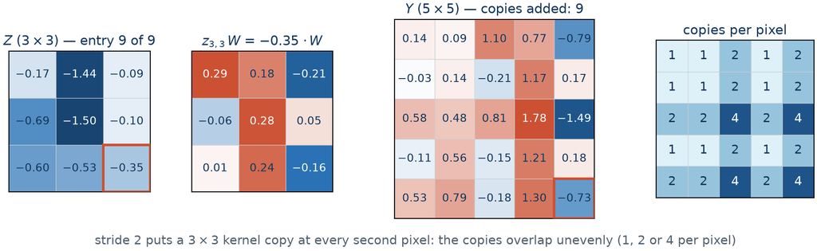

$C^\top \operatorname{vec}(Z)$ is a **scatter**: each entry of $Z$ adds a weighted kernel copy; with $3 \times 3$ and stride 2 the copies overlap $1$ / $2$ / $4$ times → the **checkerboard artefact**.

## Transposed convolution — the checkerboard on a face

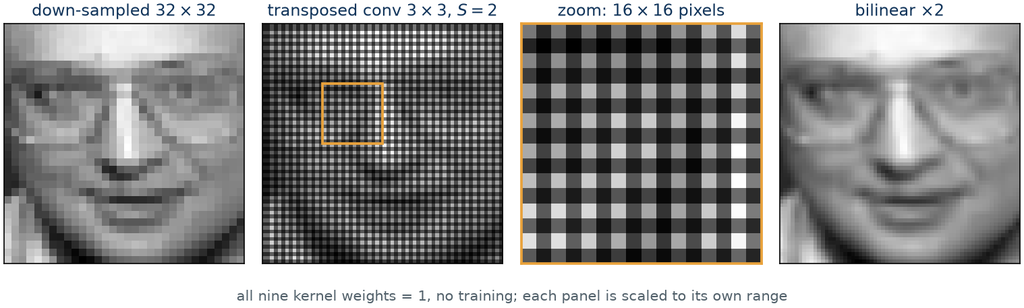

No training, all nine weights $1$: the output pixels with **4 copies** are about $4\times$ brighter than those with **1** — the face is buried under the grid. Bilinear up-sampling of the same map is smooth.

## Playground: where does the checkerboard come from?

[interactive chart not shown]

A transposed convolution drops one F × F kernel copy per input pixel, S pixels apart. The numbers = **copies per output pixel**. first copy second copy

input map N × N, **N** =

kernel **F** × F, F =

stride **S** =

## Long skips + concatenation = U-Net

- **Encoder:** pooling or strided convolutions shrink the map — the spatial bottleneck
- **Decoder:** unpooling, transposed convolution or interpolation grow it back
- **Long skips:** every encoder map is **concatenated** to the decoder map of the same size

The bottleneck tells the decoder **what** is in the image, the long skips tell it **where** — the U-Net of the next lecture.

## 6 · Attention module

> Not every pixel and not every feature map deserves the same weight.

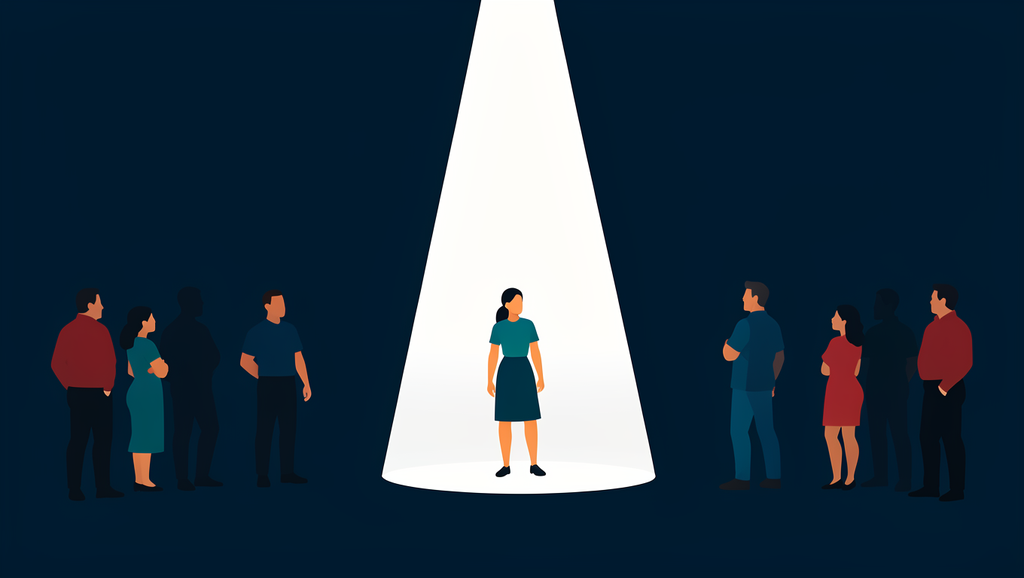

Illustration generated by AI (FLUX.2)

## Attention module

- first the **global context**, then the details at full resolution
- **Attention map:** a learned weight map (values 0–1) that says where the area of interest is; it **multiplies** the activation map
- computed **from the content**, unlike the fixed weights of a convolution

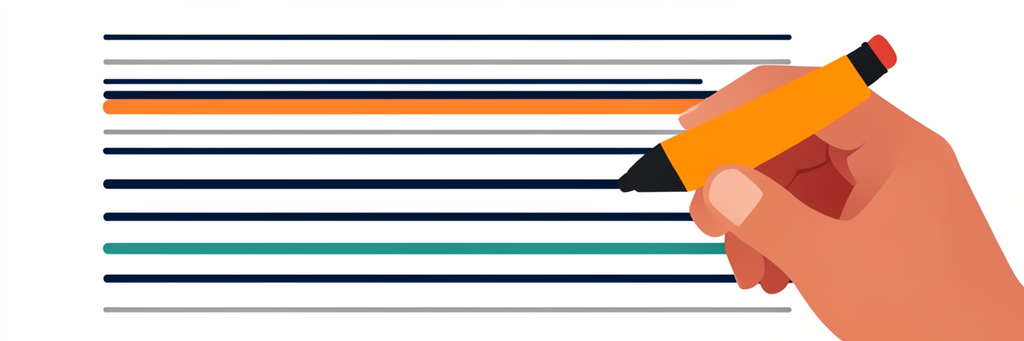

Illustration generated by AI (FLUX.2)

✓ Pros

- context information for little computation
- spatial context for **segmentation**
- the basic unit of **transformers** (self-attention)

✗ Cons

- self-attention costs grow **quadratically** with the number of positions

## Channel attention — squeeze and excitation

**Squeeze:** global average pooling, one number $s_d$ per channel · **Excitation:** a small multilayer perceptron (MLP) $D \to D/r \to D$ and a sigmoid · **Rescale:** every channel times its weight

$$M_{\text{ch}} = \sigma\big(W_2 \operatorname{ReLU}(W_1 \mathbf s)\big),
\qquad A' = M_{\text{ch}} \odot A$$

[figure not shown]

Hu et al., *Squeeze-and-Excitation Networks*, CVPR 2018 ([arXiv:1709.01507](https://arxiv.org/abs/1709.01507)).

## Channel attention in CBAM

Input

map $A$, $W \times H \times D$

Output

$M_{\text{ch}}$: one weight per channel, $1 \times 1 \times D$

Hyperparameters

MLP size (reduction ratio $r$)

Learned parameters

the shared MLP

[figure not shown]

CBAM (convolutional block attention module) squeezes each channel **twice** — global max and average pooling — sends both vectors through the **same** MLP and adds the two scores before the sigmoid.

Drawn after Woo et al., *CBAM: Convolutional Block Attention Module*, ECCV 2018 ([arXiv:1807.06521](https://arxiv.org/abs/1807.06521)).

## Spatial attention and CBAM

[figure not shown]

Drawn after Woo et al., *CBAM: Convolutional Block Attention Module*, ECCV 2018 ([arXiv:1807.06521](https://arxiv.org/abs/1807.06521)).

## The same blocks in PyTorch

```python
# residual block (a): 74 112 parameters
f = nn.Sequential(
    nn.Conv2d(64, 64, 3, padding=1),
    nn.BatchNorm2d(64), nn.ReLU(),
    nn.Conv2d(64, 64, 3, padding=1),
    nn.BatchNorm2d(64))
y = torch.relu(f(x) + x)

nn.Conv2d(256, 64, 1)      # 1 × 1: 16 448
# bottleneck 256 → 64 → 64 → 256: 69 632
nn.Sequential(nn.Conv2d(256, 64, 1, bias=False),
    nn.Conv2d(64, 64, 3, padding=1, bias=False),
    nn.Conv2d(64, 256, 1, bias=False))
```

```python
# δ = 2, P = 2: 36 928 parameters, W × H kept
nn.Conv2d(64, 64, 3, padding=2, dilation=2)

pool = nn.MaxPool2d(2, return_indices=True)
z, idx = pool(x)                 # idx = switches
u = nn.MaxUnpool2d(2)(z, idx)    # 0 parameters

# 16 × 16 → 32 × 32: 18 464 parameters
nn.ConvTranspose2d(64, 32, 3, stride=2,
                   padding=1, output_padding=1)

# SE block, r = 16: 580 parameters
se = nn.Sequential(nn.AdaptiveAvgPool2d(1),
    nn.Conv2d(64, 4, 1), nn.ReLU(),
    nn.Conv2d(4, 64, 1), nn.Sigmoid())
y = se(x) * x
```

Tensors are $(N, C, H, W)$: $C$ = our depth $D$. `kernel_size` = $F$, `stride` = $S$, `padding` = $P$, `dilation` = $\delta$, `out_channels` = $K$.

## 7 · Recap

> Today’s blocks are the ingredients — most of the architectures of the next lecture are cooked from them.

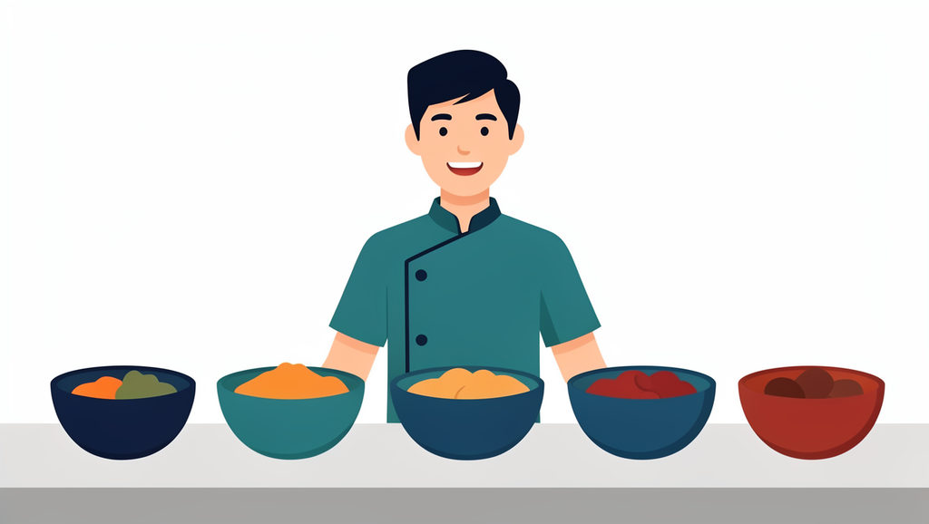

Illustration generated by AI (FLUX.2)

## Summary — the six blocks

1 · Skip connections

- carry information and gradient past several layers
- joined by concatenation or addition

2 · Residual block

- learns $\mathcal F(\mathbf x) = \mathcal H(\mathbf x) - \mathbf x$
- the identity is easy, so depth hurts much less

3 · 1 × 1 convolution, bottleneck

- mixes features in depth only
- 512 → 64 → 64 → 512: 23 × cheaper (ResNet-50 block)

4 · Dilated convolution

- larger receptive field, same 9 weights
- no down-sampling, full resolution kept

5 · Shrink and grow back

- autoencoder, spatial bottleneck
- unpooling, transposed convolution, interpolation → U-Net

6 · Attention

- a learned 0–1 map multiplies the activations
- channel ($M_{\text{ch}}$) and spatial ($M_{\text{sp}}$)

## Recap quiz I — blocks 1 to 3

Skip connections

- What are the two ways of **joining** activation maps? What must hold about the tensor shapes in each, and what happens to the depth?

Residual block

- Write the definition of the **residual** $\mathcal F(\mathbf x)$. Why is it easier to learn than $\mathcal H(\mathbf x)$ itself?
- Why does a residual branch help against **vanishing gradients**? Which term appears in the Jacobian?
- By hand: $y = f(wx)$ against $y = x + f(wx)$ with $f = \tanh$, $w = 0.1$, $x = 0$. What is $dy/dx$ for each, and for a chain of ten such layers?

1 × 1 convolution and bottleneck

- A $1 \times 1$ convolution turns $W \times H \times 16$ into $W \times H \times 4$. How many weights and biases does it have?
- Why is a $1 \times 1$ convolution on a $1 \times 1 \times D$ tensor the same thing as a fully connected layer?
- In the bottleneck block $512 \to 64 \to 64 \to 512$ — where exactly does the saving come from, and what is the price?

## Recap quiz II — blocks 4 to 6

Dilated convolution

- What does the dilation $\delta$ multiply in the formula — the position $(i, j)$ in the **image** or the **kernel offsets** $u, v$? What would the other option do?
- A chain of $3 \times 3$ convolutions with $\delta = 1, 2, 4$ — what is the receptive field, and how many weights does it use?

Shrink and grow back

- What are **switch variables**? How many of the $16$ values of a $4 \times 4$ map survive a $2 \times 2$ pooling?
- What is the size of the convolution matrix $C$ for $M = 8$, stride 1 and stride 2? Why can it not be inverted in the second case?
- Why is “deconvolution” the wrong name for a transposed convolution?
- By hand: the 1D transposed convolution of $[a, b]$, kernel $[1, 2, 1]$, stride 2?

Attention

- **Channel** versus **spatial** attention: what is pooled away in each, and what is the shape of the resulting attention map?